# Assignment 3

```python
import numpy as np
import pandas as pd
import matplotlib.pyplot as plt
import seaborn as sns
sns.set()
```

```python
data = pd.read_csv(r"C:\Users\Niranjan.p\Documents\GitHub\Machine_Learning_USU\Spring 2020\HW\HW2-EDA (answer key)\nyc-rolling-sales_clean.csv")
```

```python
seed_no = 1000
```

```python
pd.set_option('display.max_rows',100) ## maximum number of rows the panda will display
pd.set_option('display.max_columns',30)### for the visualization of all the coluamns
data.head(5)
```

|  | BOROUGH | NEIGHBORHOOD | BUILDING CLASS CATEGORY | TAX CLASS AT PRESENT | BUILDING CLASS AT PRESENT | ZIP CODE | RESIDENTIAL UNITS | COMMERCIAL UNITS | TOTAL UNITS | LAND SQUARE FEET | GROSS SQUARE FEET | YEAR BUILT | TAX CLASS AT TIME OF SALE | BUILDING CLASS AT TIME OF SALE | SALE PRICE | SALE DATE | sale_year | sale_month |
| --- | --- | --- | --- | --- | --- | --- | --- | --- | --- | --- | --- | --- | --- | --- | --- | --- | --- | --- |
| 0 | Manhattan | ALPHABET CITY | 07 RENTALS - WALKUP APARTMENTS | 2B | C4 | 10009 | 10 | 0 | 10 | 2272.0 | 6794.0 | 1913 | 2 | C4 | 3936272.0 | 2016-09-23 | 2016 | 9 |
| 1 | Manhattan | ALPHABET CITY | 07 RENTALS - WALKUP APARTMENTS | 2B | C4 | 10009 | 8 | 0 | 8 | 1750.0 | 4226.0 | 1920 | 2 | C4 | 3192840.0 | 2016-09-23 | 2016 | 9 |
| 2 | Manhattan | ALPHABET CITY | 14 RENTALS - 4-10 UNIT | 2A | S3 | 10009 | 3 | 1 | 4 | 1520.0 | 3360.0 | 1910 | 2 | S3 | 3300000.0 | 2016-11-15 | 2016 | 11 |
| 3 | Manhattan | ALPHABET CITY | 22 STORE BUILDINGS | 4 | K4 | 10009 | 0 | 1 | 1 | 1218.0 | 3586.0 | 1899 | 4 | K4 | 3700000.0 | 2016-09-28 | 2016 | 9 |
| 4 | Manhattan | CHELSEA | 07 RENTALS - WALKUP APARTMENTS | 2B | C4 | 10011 | 9 | 0 | 9 | 1566.0 | 6330.0 | 1901 | 2 | C4 | 1583840.0 | 2017-08-31 | 2017 | 8 |

```python
data.info()
```

```
<class 'pandas.core.frame.DataFrame'>
RangeIndex: 30236 entries, 0 to 30235
Data columns (total 18 columns):
 #   Column                          Non-Null Count  Dtype
---  ------                          --------------  -----
 0   BOROUGH                         30236 non-null  object
 1   NEIGHBORHOOD                    30236 non-null  object
 2   BUILDING CLASS CATEGORY         30236 non-null  object
 3   TAX CLASS AT PRESENT            30236 non-null  object
 4   BUILDING CLASS AT PRESENT       30236 non-null  object
 5   ZIP CODE                        30236 non-null  int64
 6   RESIDENTIAL UNITS               30236 non-null  int64
 7   COMMERCIAL UNITS                30236 non-null  int64
 8   TOTAL UNITS                     30236 non-null  int64
 9   LAND SQUARE FEET                30236 non-null  float64
 10  GROSS SQUARE FEET               30236 non-null  float64
 11  YEAR BUILT                      30236 non-null  int64
 12  TAX CLASS AT TIME OF SALE       30236 non-null  int64
 13  BUILDING CLASS AT TIME OF SALE  30236 non-null  object
 14  SALE PRICE                      30236 non-null  float64
 15  SALE DATE                       30236 non-null  object
 16  sale_year                       30236 non-null  int64
 17  sale_month                      30236 non-null  int64
dtypes: float64(3), int64(8), object(7)
memory usage: 4.2+ MB
```

```python
data.describe(include='all')
```

|  | BOROUGH | NEIGHBORHOOD | BUILDING CLASS CATEGORY | TAX CLASS AT PRESENT | BUILDING CLASS AT PRESENT | ZIP CODE | RESIDENTIAL UNITS | COMMERCIAL UNITS | TOTAL UNITS | LAND SQUARE FEET | GROSS SQUARE FEET | YEAR BUILT | TAX CLASS AT TIME OF SALE | BUILDING CLASS AT TIME OF SALE | SALE PRICE | SALE DATE | sale_year | sale_month |
| --- | --- | --- | --- | --- | --- | --- | --- | --- | --- | --- | --- | --- | --- | --- | --- | --- | --- | --- |
| count | 30236 | 30236 | 30236 | 30236 | 30236 | 30236.000000 | 30236.000000 | 30236.000000 | 30236.000000 | 3.023600e+04 | 3.023600e+04 | 30236.000000 | 30236.000000 | 30236 | 3.023600e+04 | 30236 | 30236.000000 | 30236.000000 |
| unique | 5 | 242 | 38 | 9 | 115 | NaN | NaN | NaN | NaN | NaN | NaN | NaN | NaN | 115 | NaN | 327 | NaN | NaN |
| top | Brooklyn | FLUSHING-NORTH | 01 ONE FAMILY DWELLINGS | 1 | A1 | NaN | NaN | NaN | NaN | NaN | NaN | NaN | NaN | A1 | NaN | 2017-04-28 | NaN | NaN |
| freq | 11042 | 759 | 12473 | 24441 | 4692 | NaN | NaN | NaN | NaN | NaN | NaN | NaN | NaN | 4687 | NaN | 206 | NaN | NaN |
| mean | NaN | NaN | NaN | NaN | NaN | 11034.538365 | 1.970532 | 0.173039 | 2.147804 | 3.133582e+03 | 2.440363e+03 | 1946.632160 | 1.249768 | NaN | 7.938200e+05 | NaN | 2016.649623 | 6.562343 |
| std | NaN | NaN | NaN | NaN | NaN | 480.032918 | 12.586963 | 13.034598 | 18.198705 | 2.796632e+04 | 2.380024e+04 | 35.033054 | 0.632240 | NaN | 5.947252e+05 | NaN | 0.477096 | 3.477355 |
| min | NaN | NaN | NaN | NaN | NaN | 0.000000 | 0.000000 | 0.000000 | 1.000000 | 0.000000e+00 | 0.000000e+00 | 1800.000000 | 1.000000 | NaN | 1.000100e+04 | NaN | 2016.000000 | 1.000000 |
| 25% | NaN | NaN | NaN | NaN | NaN | 10468.000000 | 1.000000 | 0.000000 | 1.000000 | 1.816500e+03 | 1.208000e+03 | 1920.000000 | 1.000000 | NaN | 4.360000e+05 | NaN | 2016.000000 | 4.000000 |
| 50% | NaN | NaN | NaN | NaN | NaN | 11221.000000 | 1.000000 | 0.000000 | 1.000000 | 2.417000e+03 | 1.680000e+03 | 1935.000000 | 1.000000 | NaN | 6.300000e+05 | NaN | 2017.000000 | 6.000000 |
| 75% | NaN | NaN | NaN | NaN | NaN | 11368.000000 | 2.000000 | 0.000000 | 2.000000 | 3.500000e+03 | 2.392000e+03 | 1970.000000 | 1.000000 | NaN | 9.400000e+05 | NaN | 2017.000000 | 10.000000 |
| max | NaN | NaN | NaN | NaN | NaN | 11694.000000 | 1844.000000 | 2261.000000 | 2261.000000 | 4.228300e+06 | 3.750565e+06 | 2017.000000 | 4.000000 | NaN | 3.995000e+06 | NaN | 2017.000000 | 12.000000 |

### Importing from csv some of the variable losses its type so again chnaging variable type

I am not sure but i think saving the file to pickle format may preserve the category (Like in R we save as .Rdata because in csv it loses the property of variable)

```python
categorical = ['BOROUGH','ZIP CODE', 'TAX CLASS AT TIME OF SALE']

for col in categorical:
    data[col] = data[col].astype("category")
```

### Adding one column age of the property from the year of sale and year built.

```python
data["Age"] = data["sale_year"]-data['YEAR BUILT']
```

```python
data.head(5)
```

|  | BOROUGH | NEIGHBORHOOD | BUILDING CLASS CATEGORY | TAX CLASS AT PRESENT | BUILDING CLASS AT PRESENT | ZIP CODE | RESIDENTIAL UNITS | COMMERCIAL UNITS | TOTAL UNITS | LAND SQUARE FEET | GROSS SQUARE FEET | YEAR BUILT | TAX CLASS AT TIME OF SALE | BUILDING CLASS AT TIME OF SALE | SALE PRICE | SALE DATE | sale_year | sale_month | Age |
| --- | --- | --- | --- | --- | --- | --- | --- | --- | --- | --- | --- | --- | --- | --- | --- | --- | --- | --- | --- |
| 0 | Manhattan | ALPHABET CITY | 07 RENTALS - WALKUP APARTMENTS | 2B | C4 | 10009 | 10 | 0 | 10 | 2272.0 | 6794.0 | 1913 | 2 | C4 | 3936272.0 | 2016-09-23 | 2016 | 9 | 103 |
| 1 | Manhattan | ALPHABET CITY | 07 RENTALS - WALKUP APARTMENTS | 2B | C4 | 10009 | 8 | 0 | 8 | 1750.0 | 4226.0 | 1920 | 2 | C4 | 3192840.0 | 2016-09-23 | 2016 | 9 | 96 |
| 2 | Manhattan | ALPHABET CITY | 14 RENTALS - 4-10 UNIT | 2A | S3 | 10009 | 3 | 1 | 4 | 1520.0 | 3360.0 | 1910 | 2 | S3 | 3300000.0 | 2016-11-15 | 2016 | 11 | 106 |
| 3 | Manhattan | ALPHABET CITY | 22 STORE BUILDINGS | 4 | K4 | 10009 | 0 | 1 | 1 | 1218.0 | 3586.0 | 1899 | 4 | K4 | 3700000.0 | 2016-09-28 | 2016 | 9 | 117 |
| 4 | Manhattan | CHELSEA | 07 RENTALS - WALKUP APARTMENTS | 2B | C4 | 10011 | 9 | 0 | 9 | 1566.0 | 6330.0 | 1901 | 2 | C4 | 1583840.0 | 2017-08-31 | 2017 | 8 | 116 |

### Some categorical variable are really large so reducing them for linear regression analysis

## BUILDING CLASS CATEGORY

```python
temp = data['BUILDING CLASS CATEGORY'].value_counts()
print(temp)
```

```
01 ONE FAMILY DWELLINGS                         12473
02 TWO FAMILY DWELLINGS                          9672
03 THREE FAMILY DWELLINGS                        2274
13 CONDOS - ELEVATOR APARTMENTS                  1779
07 RENTALS - WALKUP APARTMENTS                   1311
15 CONDOS - 2-10 UNIT RESIDENTIAL                 658
04 TAX CLASS 1 CONDOS                             373
22 STORE BUILDINGS                                344
14 RENTALS - 4-10 UNIT                            282
12 CONDOS - WALKUP APARTMENTS                     239
29 COMMERCIAL GARAGES                             131
44 CONDO PARKING                                  124
21 OFFICE BUILDINGS                               122
30 WAREHOUSES                                     120
27 FACTORIES                                       69
```

[output cut: 24 more lines]

```python
temp1 = temp[:6].index # Getting top 6 values
data['BUILDING CLASS CATEGORY'] = data['BUILDING CLASS CATEGORY'].where(data['BUILDING CLASS CATEGORY'].isin(temp1),'Other')
## The above step assigns other to less frequent categories beside the top 6 mentioned above
```

## TAX CLASS AT PRESENT

```python
temp = data['TAX CLASS AT PRESENT'].value_counts()
temp1 = temp[:5].index # Getting top 5 values
data['TAX CLASS AT PRESENT'] = data['TAX CLASS AT PRESENT'].where(data['TAX CLASS AT PRESENT'].isin(temp1),'Other')
```

### BUILDING CLASS AT PRESENT

```python
temp = data['BUILDING CLASS AT PRESENT'].value_counts()
temp1 = temp[:10].index # Getting top 10 values
data['BUILDING CLASS AT PRESENT'] = data['BUILDING CLASS AT PRESENT'].where(data['BUILDING CLASS AT PRESENT'].isin(temp1),'Other')
```

### BUILDING CLASS AT THE TIME OF SALE

```python
temp = data['BUILDING CLASS AT TIME OF SALE'].value_counts()
temp1 = temp[:10].index # Getting top 10 values
data['BUILDING CLASS AT TIME OF SALE'] = data['BUILDING CLASS AT TIME OF SALE'].where(data['BUILDING CLASS AT TIME OF SALE'].isin(temp1),'Other')
```

### Changing some required classes into category

```python
categorical = ['BUILDING CLASS CATEGORY','TAX CLASS AT PRESENT', 'BUILDING CLASS AT PRESENT','BUILDING CLASS AT TIME OF SALE','sale_year','sale_month',
               'NEIGHBORHOOD']

for col in categorical:
    data[col] = data[col].astype("category")
```

```python
data.describe(include='all')
```

|  | BOROUGH | NEIGHBORHOOD | BUILDING CLASS CATEGORY | TAX CLASS AT PRESENT | BUILDING CLASS AT PRESENT | ZIP CODE | RESIDENTIAL UNITS | COMMERCIAL UNITS | TOTAL UNITS | LAND SQUARE FEET | GROSS SQUARE FEET | YEAR BUILT | TAX CLASS AT TIME OF SALE | BUILDING CLASS AT TIME OF SALE | SALE PRICE | SALE DATE | sale_year | sale_month | Age |
| --- | --- | --- | --- | --- | --- | --- | --- | --- | --- | --- | --- | --- | --- | --- | --- | --- | --- | --- | --- |
| count | 30236 | 30236 | 30236 | 30236 | 30236 | 30236.0 | 30236.000000 | 30236.000000 | 30236.000000 | 3.023600e+04 | 3.023600e+04 | 30236.000000 | 30236.0 | 30236 | 3.023600e+04 | 30236 | 30236.0 | 30236.0 | 30236.000000 |
| unique | 5 | 242 | 7 | 6 | 11 | 171.0 | NaN | NaN | NaN | NaN | NaN | NaN | 3.0 | 11 | NaN | 327 | 2.0 | 12.0 | NaN |
| top | Brooklyn | FLUSHING-NORTH | 01 ONE FAMILY DWELLINGS | 1 | Other | 10314.0 | NaN | NaN | NaN | NaN | NaN | NaN | 1.0 | Other | NaN | 2017-04-28 | 2017.0 | 6.0 | NaN |
| freq | 11042 | 759 | 12473 | 24441 | 5352 | 835.0 | NaN | NaN | NaN | NaN | NaN | NaN | 24824.0 | 5339 | NaN | 206 | 19642.0 | 2931.0 | NaN |
| mean | NaN | NaN | NaN | NaN | NaN | NaN | 1.970532 | 0.173039 | 2.147804 | 3.133582e+03 | 2.440363e+03 | 1946.632160 | NaN | NaN | 7.938200e+05 | NaN | NaN | NaN | 70.017463 |
| std | NaN | NaN | NaN | NaN | NaN | NaN | 12.586963 | 13.034598 | 18.198705 | 2.796632e+04 | 2.380024e+04 | 35.033054 | NaN | NaN | 5.947252e+05 | NaN | NaN | NaN | 35.037050 |
| min | NaN | NaN | NaN | NaN | NaN | NaN | 0.000000 | 0.000000 | 1.000000 | 0.000000e+00 | 0.000000e+00 | 1800.000000 | NaN | NaN | 1.000100e+04 | NaN | NaN | NaN | 0.000000 |
| 25% | NaN | NaN | NaN | NaN | NaN | NaN | 1.000000 | 0.000000 | 1.000000 | 1.816500e+03 | 1.208000e+03 | 1920.000000 | NaN | NaN | 4.360000e+05 | NaN | NaN | NaN | 47.000000 |
| 50% | NaN | NaN | NaN | NaN | NaN | NaN | 1.000000 | 0.000000 | 1.000000 | 2.417000e+03 | 1.680000e+03 | 1935.000000 | NaN | NaN | 6.300000e+05 | NaN | NaN | NaN | 82.000000 |
| 75% | NaN | NaN | NaN | NaN | NaN | NaN | 2.000000 | 0.000000 | 2.000000 | 3.500000e+03 | 2.392000e+03 | 1970.000000 | NaN | NaN | 9.400000e+05 | NaN | NaN | NaN | 96.000000 |
| max | NaN | NaN | NaN | NaN | NaN | NaN | 1844.000000 | 2261.000000 | 2261.000000 | 4.228300e+06 | 3.750565e+06 | 2017.000000 | NaN | NaN | 3.995000e+06 | NaN | NaN | NaN | 217.000000 |

### In this part we will first drop the variables we will not be using in our regression analysis

```python
data=data.drop(['NEIGHBORHOOD','ZIP CODE','YEAR BUILT','SALE DATE','sale_year'],axis=1) # Check year built
## NEIGHBORHOOD have high number of categories
## ZIP CODE has high number of categories
## YEAR BUILT and sale_year is used to find the age of the category so kind of already used
## Sale date is removed because we are not doing time series regression
```

```python
data.info()
```

```
<class 'pandas.core.frame.DataFrame'>
RangeIndex: 30236 entries, 0 to 30235
Data columns (total 14 columns):
 #   Column                          Non-Null Count  Dtype
---  ------                          --------------  -----
 0   BOROUGH                         30236 non-null  category
 1   BUILDING CLASS CATEGORY         30236 non-null  category
 2   TAX CLASS AT PRESENT            30236 non-null  category
 3   BUILDING CLASS AT PRESENT       30236 non-null  category
 4   RESIDENTIAL UNITS               30236 non-null  int64
 5   COMMERCIAL UNITS                30236 non-null  int64
 6   TOTAL UNITS                     30236 non-null  int64
 7   LAND SQUARE FEET                30236 non-null  float64
 8   GROSS SQUARE FEET               30236 non-null  float64
 9   TAX CLASS AT TIME OF SALE       30236 non-null  category
 10  BUILDING CLASS AT TIME OF SALE  30236 non-null  category
 11  SALE PRICE                      30236 non-null  float64
 12  sale_month                      30236 non-null  category
 13  Age                             30236 non-null  int64
dtypes: category(7), float64(3), int64(4)
memory usage: 1.8 MB
```

### Checking for the y-variable

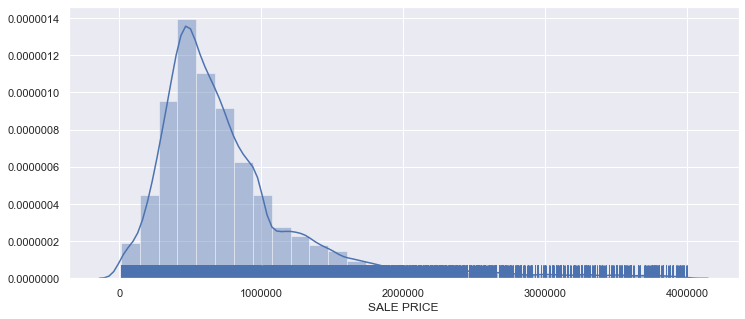

```python
plt.figure(figsize=(12,5))
sns.distplot(data['SALE PRICE'], bins=30,rug=True)
plt.show()
```

### Lets do the log transformation of the y-variable

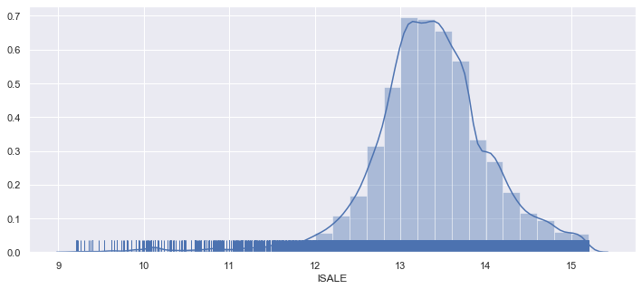

```python
plt.figure(figsize=(12,5))
data['lSALE']=np.log(data['SALE PRICE'])
sns.distplot(data['lSALE'],bins=30, rug= True)
plt.show()
```

```python
data.drop('SALE PRICE',axis=1,inplace=True)
```

### Checking for highly correlated variables

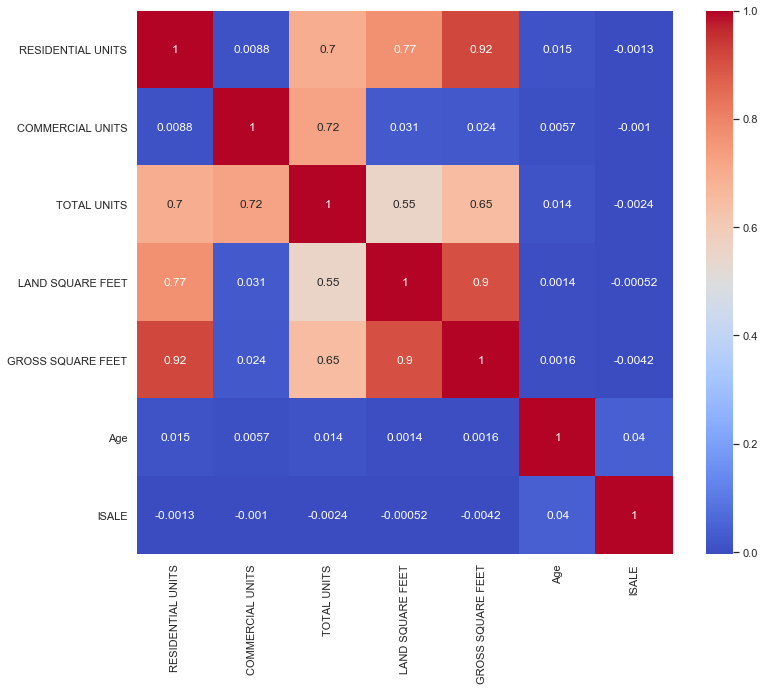

```python
plt.figure(figsize=(12,10))
sns.heatmap(data.corr(), cmap='coolwarm',annot=True)
plt.show()
```

### Removing highly correlated variables fom the datset

```python
data.drop(['RESIDENTIAL UNITS','LAND SQUARE FEET','COMMERCIAL UNITS'],axis=1,inplace=True)
```

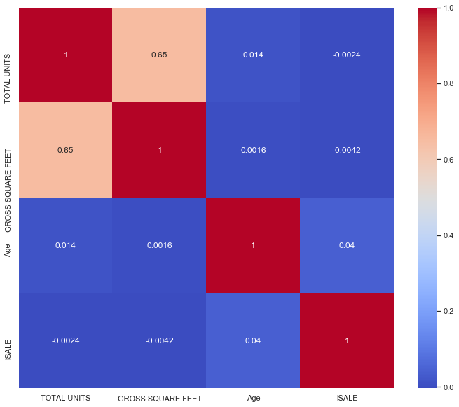

```python
plt.figure(figsize=(12,10))
sns.heatmap(data.corr(), cmap='coolwarm',annot=True)
plt.show()
```

### Cheking variables in feature space

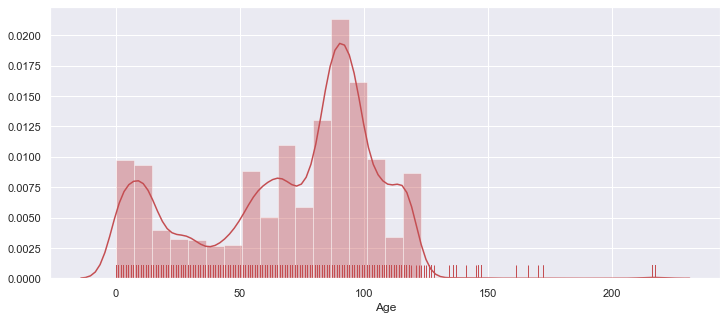

```python
plt.figure(figsize=(12,5))
sns.distplot(data['Age'], bins=30 ,color='r' , rug=True)
```

```python
print((data['Age']>150).sum())
```

```
30
```

#### Removing some outliers influencing the prediction

```python
data=data[data['Age']<150]
```

### Log transforming age variable

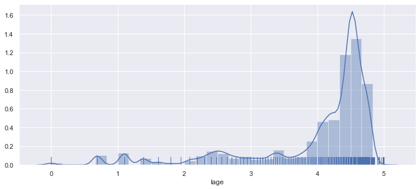

```python
plt.figure(figsize=(12,5))
data['lage']=np.log(data['Age'] + 1) ## There are some zero in age value which makes log transformation not feasible so adding 1 which might not affect that much
sns.distplot(data['lage'],bins=30, rug= True)
plt.show()
```

Here we didnot remove zero because the property might have been built and sold in same year so instead added one to use log transformation.

```python
data.drop('Age',axis=1,inplace=True)
```

### Gross square feet variable

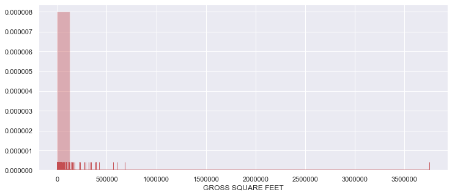

```python
plt.figure(figsize=(12,5))
sns.distplot(data['GROSS SQUARE FEET'], bins=30 ,color='r' , rug=True)
```

```python
data = data[data['GROSS SQUARE FEET']>200]
```

```python
print((data['GROSS SQUARE FEET']>50000).sum())
```

```
67
```

```python
data=data[data['GROSS SQUARE FEET']<50000]
```

Like wise we removed some outliers and observations which might be faulty because area less than some square feet doesnot make sense.

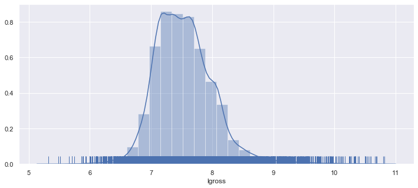

```python
plt.figure(figsize=(12,5))
data['lgross']=np.log(data['GROSS SQUARE FEET'] )
sns.distplot(data['lgross'],bins=30, rug= True)
plt.show()
```

```python
data.drop('GROSS SQUARE FEET',axis=1,inplace=True)
```

```python
#plt.figure(figsize=(12,10))
#sns.boxplot(x=data['lgross'])
```

### Total units variable

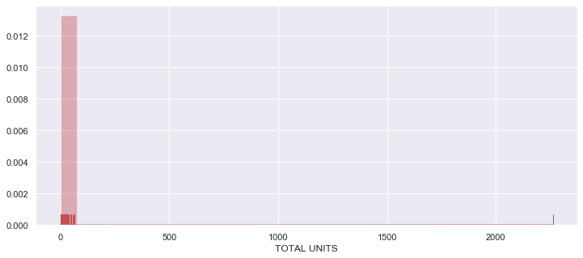

```python
plt.figure(figsize=(12,5))
sns.distplot(data['TOTAL UNITS'], bins=30 ,color='r' , rug=True)
```

```python
print((data['TOTAL UNITS']>300).sum())
```

```
1
```

```python
### removing these extra high number of total units which might hamper our estimation
```

```python
data = data[data['TOTAL UNITS']<350]
```

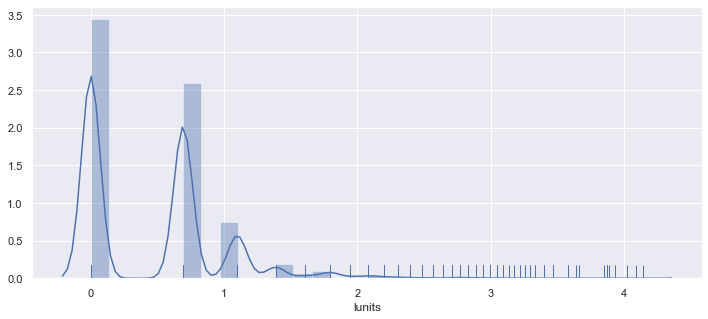

```python
plt.figure(figsize=(12,5))
data['lunits']=np.log(data['TOTAL UNITS'])
sns.distplot(data['lunits'],bins=30, rug= True)
plt.show()
```

```python
data= pd.get_dummies(data,drop_first=True) ### Creating dummies for categorical variables
```

### Defining the variables and splitting the data

```python
y = data['lSALE']
X = data.drop('lSALE', axis=1)

from sklearn.model_selection import train_test_split
X_train, X_test, y_train, y_test = train_test_split(X, y, test_size=0.2, random_state=seed_no)

len(X_train)/len(X)
```

```
0.7999851151713616
```

```python
from sklearn.linear_model import LinearRegression
```

```python
sklearn_reg = LinearRegression()
```

```python
sklearn_reg.fit(X_train,y_train)
```

```
LinearRegression(copy_X=True, fit_intercept=True, n_jobs=None, normalize=False)
```

```python
sklearn_reg.predict(X_test)[0:4]
```

```
array([13.06975916, 12.99578354, 13.19371715, 13.92130002])
```

```python
y_hat_test = sklearn_reg.predict(X_test)
log_predictions = pd.DataFrame({'Actuals':y_test, 'Predictions':y_hat_test})
predictions = np.exp(log_predictions)
predictions.head()
```

|  | Actuals | Predictions |
| --- | --- | --- |
| 25563 | 400000.0 | 4.743777e+05 |
| 30157 | 570000.0 | 4.405519e+05 |
| 22528 | 400000.0 | 5.369805e+05 |
| 7172 | 3500000.0 | 1.111588e+06 |
| 1779 | 450000.0 | 4.741652e+05 |

```python
MSE_test = round(np.mean(np.square(predictions['Actuals'] - predictions['Predictions'])),2)
MSE_test
```

```
220874430873.74
```

```python
RMSE_test = round(np.sqrt(MSE_test),2)
RMSE_test
```

```
469972.8
```

Our RMSE is less than 473,298 by little margin

```python
R2 = sklearn_reg.score(X_train,y_train)
```

```python
R2
```

```
0.2889876373870818
```

## MSE In logarithmic also

```python
y_hat_test1 = sklearn_reg.predict(X_test)
predictions1 = pd.DataFrame({'Actuals':y_test, 'Predictions':y_hat_test1})
predictions1.head()
```

|  | Actuals | Predictions |
| --- | --- | --- |
| 25563 | 12.899220 | 13.069759 |
| 30157 | 13.253392 | 12.995784 |
| 22528 | 12.899220 | 13.193717 |
| 7172 | 15.068274 | 13.921300 |
| 1779 | 13.017003 | 13.069311 |

```python
MSE_test1 = round(np.mean(np.square(predictions1['Actuals'] - predictions1['Predictions'])),6)
MSE_test1
```

```
0.356558
```

```python
RMSE_test1 = round(np.sqrt(MSE_test1),6)
RMSE_test1
```

```
0.597125
```

```python
#sns.scatterplot(x=y_test, y=y_hat_test, alpha=0.6)
#sns.lineplot(y_test, y_test)

#plt.xlabel('Actual log wage', fontsize=14)
#plt.ylabel('Prediced log wage', fontsize=14)
#plt.title('Actual vs Predicted log wage (test set)', fontsize=17)
#plt.show()
```

### Next procedding towards cross validation

```python
from sklearn.model_selection import cross_val_score
import sklearn.metrics
```

```python
model= LinearRegression()
```

```python
#sorted(sklearn.metrics.SCORERS.keys())
```

```python
NMSE = cross_val_score(estimator=model,X=X_test,y=y_test,cv=5,scoring="neg_mean_squared_error")
NMSE
```

```
array([-0.42838083, -0.31642881, -0.40122682, -0.31998421, -0.35478501])
```

```python
RMSE = np.sqrt(-NMSE)
RMSE
```

```
array([0.65450808, 0.56252005, 0.63342468, 0.56567147, 0.59563833])
```

```python
RMSE.mean()
```

```
0.6023525214920198
```

### 10 fold cross validation

```python
NMSE = cross_val_score(estimator=model,X=X_test,y=y_test,cv=10,scoring="neg_mean_squared_error")
NMSE
```

```
array([-0.42832706, -0.42316555, -0.26730509, -0.36242035, -0.36157134,
       -0.42375265, -0.36866694, -0.26392509, -0.36367193, -0.34402222])
```

```python
RMSE = np.sqrt(-NMSE)
RMSE
```

```
array([0.65446701, 0.65051176, 0.51701556, 0.60201358, 0.60130803,
       0.65096286, 0.6071795 , 0.5137364 , 0.60305218, 0.58653407])
```

```python
RMSE.mean()
```

```
0.598678094050583
```

Our y-variable is log transformed variable and the MSE reported is also in log scale but its been hard to figure out how to convert these into normal scale so we also had a log transformed mse in our previous RMSE of test set without validation just to compare.

### RMSE_test reported from the cross validation with 10 number of k-fold:0.598678094050583

We can see that the RMSE value from the cross validation are gretaer than the RMSE of test set as expected beacuse in the cross validation as disscused some part of the observation is new to the model.

### Below we will do a cross-validation in train set which might help us to compare with the test set Rsme from without cross validation.

```python
NMSE = cross_val_score(estimator=model,X=X_train,y=y_train,cv=5,scoring="neg_mean_squared_error")
RMSE = np.sqrt(-NMSE)
RMSE.mean()
```

```
0.5780035796783219
```

```python
NMSE = cross_val_score(estimator=model,X=X_train,y=y_train,cv=10,scoring="neg_mean_squared_error")
RMSE = np.sqrt(-NMSE)
RMSE.mean()
```

```
0.5778533813230414
```

So from above we have, the RMSE-test set without cross validation is 0.59715 and with 5-fold cross validaton in train set it is 0.578 and with 10-fold is 0.577.RMSE from cross validation of train set is below the RMSE of the test set without cross validation which is theoritically as aspected. The test set RMSE should be higher than cross validation because test set is completely new set of data. The train set cross validation help to explain where the test set RMSE might lie which is some what observed in our analysis. (For finding the degree of polynomial regression we will look at the test set cross validation as we will see later on).

### Incorporating the nonlinearity in feature space

```python
from sklearn.preprocessing import PolynomialFeatures
```

### Our y variable is the log of sale #we can alternatively use the sale price

```python
data=data.reset_index(drop=True)
```

```python
X1=data['lgross'].values
X1 = np.exp(X1) ### Here i want to test with actual gross area, the analysis can be done with log of data as well
```

```python
y=data['lSALE']
```

```python
import statsmodels.api as sm
```

```python
def poly_reg(poly_degree, X,y,test_size=0.2,rand_state=seed_no):
    poly_features = PolynomialFeatures(degree=poly_degree)

    X_poly = pd.DataFrame(poly_features.fit_transform(X.reshape(-1,1)))
    X_train, X_test, y_train, y_test = train_test_split(X_poly,y,test_size=test_size,random_state=rand_state)

    poly_model= LinearRegression().fit(X_train,y_train) #sm.OLS(y_train,X_train).fit()

    y_train_predicted = (poly_model.predict(X_train)) ## to get mse in normal scale use np.exp(poly_model.predict(X_train))
    y_test_predicted = (poly_model.predict(X_test)) ## to get mse in normal scale use np.exp(poly_model.predict(X_test))

    MSE_train = round(np.mean(np.square(y_train-y_train_predicted)),2)
    RMSE_train = round(np.sqrt(MSE_train),2)
    #R2_train = round(poly_model.rsquared,2)
    #Adj_R2_train = round(poly_model.rsquared_adj,2)

    ###Evaluating on test set
    MSE_test = round(np.mean(np.square(y_test-y_test_predicted)),2)
    RMSE_test = round(np.sqrt(MSE_test),2)

    return poly_degree, MSE_train, MSE_test, RMSE_train, RMSE_test
```

```python
returns= []
for i in range(1,9):
    returns.append(poly_reg(poly_degree=i,X=X1,y=y))
output = pd.DataFrame(returns, columns=['Degree','MSE_train','MSE_test','RMSE_train','RMSE_test'])
output['Rmse(tr-te)'] =output['RMSE_train']-output['RMSE_test']
output
```

|  | Degree | MSE_train | MSE_test | RMSE_train | RMSE_test | Rmse(tr-te) |
| --- | --- | --- | --- | --- | --- | --- |
| 0 | 1 | 0.41 | 0.43 | 0.64 | 0.66 | -0.02 |
| 1 | 2 | 0.38 | 0.41 | 0.62 | 0.64 | -0.02 |
| 2 | 3 | 0.38 | 0.39 | 0.62 | 0.62 | 0.00 |
| 3 | 4 | 0.37 | 0.39 | 0.61 | 0.62 | -0.01 |
| 4 | 5 | 0.39 | 0.42 | 0.62 | 0.65 | -0.03 |
| 5 | 6 | 0.43 | 0.46 | 0.66 | 0.68 | -0.02 |
| 6 | 7 | 0.46 | 0.48 | 0.68 | 0.69 | -0.01 |
| 7 | 8 | 0.47 | 0.49 | 0.69 | 0.70 | -0.01 |

### Applying the elbow method (We can use exp to see in actual scale but the log-scale gives more clear picture)

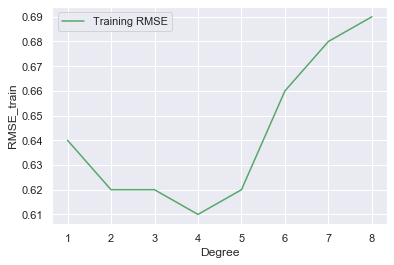

```python
sns.lineplot(x='Degree', y='RMSE_train', data=output , color='g', label="Training RMSE")
plt.show()
```

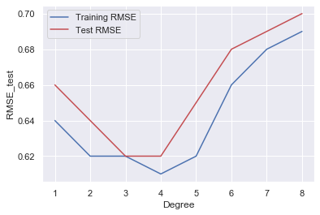

```python
sns.lineplot(x='Degree', y='RMSE_train', data=output , color='b', label="Training RMSE")
sns.lineplot(x='Degree', y='RMSE_test', data=output  ,color='r', label="Test RMSE")
```

Looking at elbow method and as weel as comparing the Rmse of test set and train set we can see that that at polynomial degree of 3 (4 is also a good one) the model performs best. Th RMSE of test is minimum and the differnce with test set is also minimum at this degree, but looking at the RMSE_test value at this degree of 3 which is 0.62 is greater than RMSE of the linear regression(rmse_test which was around 0.6). So, from our analysis simple linear regression model was better than polynomial regression we conducted. We might get differnt result using one or more feature space or log transporming the X variables so it the matter of different trials to get best fitted model.

### 5-fold cross validation try

```python
MSE_test = []
iterator = range(1,8)
for i in iterator:
    poly_features = PolynomialFeatures(degree=i)
    X_poly = pd.DataFrame(poly_features.fit_transform(X1.reshape(-1,1)))
    X_train, X_test, y_train, y_test = train_test_split(X_poly,y,test_size=0.2,random_state=233)
    poly_model=LinearRegression()  #sm.OLS(y_train,X_train).fit()
    NMSE=cross_val_score(estimator = poly_model,X=X_test,y=y_test,cv=5,scoring='neg_mean_squared_error')
    PMSE=-NMSE
    mean=PMSE.mean()
    lstn=[i,mean]
    MSE_test.append(lstn)
output = pd.DataFrame(MSE_test,columns=['Degree','MSE_test'])
output
```

|  | Degree | MSE_test |
| --- | --- | --- |
| 0 | 1 | 0.398266 |
| 1 | 2 | 0.352394 |
| 2 | 3 | 0.349719 |
| 3 | 4 | 0.346719 |
| 4 | 5 | 0.360006 |
| 5 | 6 | 0.396736 |
| 6 | 7 | 0.431082 |

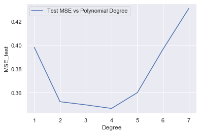

```python
sns.lineplot(x='Degree', y='MSE_test', data=output , color='b', label="Test MSE vs Polynomial Degree")
plt.show()
```

## Lets look at RMSE.

```python
output["RMSE_test"] = np.sqrt(output['MSE_test'])
```

```python
output
```

|  | Degree | MSE_test | RMSE_test |
| --- | --- | --- | --- |
| 0 | 1 | 0.398266 | 0.631083 |
| 1 | 2 | 0.352394 | 0.593628 |
| 2 | 3 | 0.349719 | 0.591371 |
| 3 | 4 | 0.346719 | 0.588829 |
| 4 | 5 | 0.360006 | 0.600005 |
| 5 | 6 | 0.396736 | 0.629870 |
| 6 | 7 | 0.431082 | 0.656569 |

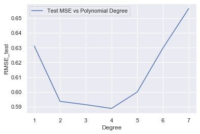

```python
sns.lineplot(x='Degree', y='RMSE_test', data=output , color='b', label="Test MSE vs Polynomial Degree")
plt.show()
```

From the cross validation of the test set it looks like 4th degree is the best option among the linear regression as it seems to have better the RMSE_test. But still the differnce between RMSE of train and test is also another major key point to look at.